# AP-4209 ESIEE-Paris: 2024 - 2025

Fouille de données avec R pour la data science et l’intelligence artificielle

TD 4 : Partie II - ANALYSE FACTORIELLE DISCRIMINANTE

–Classification supervisée–

Badr TAJINI – ESIEE Paris  
Source : Bertrand Roudier – ESIEE Paris

### 1. Introduction

Ce TD a pour objectif de réaliser la classification supervisée à l’aide de l’analyse factorielle discriminante.

Dans le précédent TD, nous avons réalisé:

- Une diminution de dimension en calculant des axes de projections qui maximisent la dispersion inter groupe. Les vecteurs directeurs de ces axes factoriels correspondent aux vecteurs propres normalisés de la matrice : $\frac{B}{W}$ (méthode Anglo-saxone)
- Les statistiques inférentielles relatives à la discrimination des groupes selon les axes (tests de Wilks)
- Le calcul des Scores. Ces derniers correspondent à la représentation des individus dans le plan formé par les (deux) premiers axes factoriels

Dans ce TD final, nous allons réaliser une classification de chaque individu dans le plan factoriel. Pour y parvenir:

- Nous calculons le centre de gravité de chaque groupe dans le plan factoriel.
- Pour chaque individu, nous calculons les distances le séparant des centres de chaque groupe.
- Nous affectons l’individu à la classe dont le centre de gravité est le plus proche.

Pour évaluer la qualité de la méthode de classification, nous réalisons une matrice de confusion.

**Rmq** : *Ce type de classification est possible que si la statistique montre préalablement l’existence significative d’une discrimination des groupes selon les axes factoriels*

### 2. Prérequis

Nous effectuons la classification en reprenant dans un premier temps les données <VIN_QUALITES.txt>. Vous utiliserez les fonctions que vous avez développées dans le TD précédent (*MANOVA* et *AFD*)  
Pour rappel, la fonction (*AFD* ) retourne une liste avec les Scores (coordonnées des individus sur les axes factoriels).

```r
# Chargement des librairies nécessaires
if(!require(ggplot2)) install.packages("ggplot2")
if(!require(caret)) install.packages("caret")
if(!require(kableExtra)) install.packages("kableExtra")
if(!require(dplyr)) install.packages("dplyr")
library(ggplot2)
library(caret)
library(kableExtra)
library(dplyr)

# Fonction MANOVA (TD précédent)

MANOVA <- function(X, Y) {
  X <- as.matrix(X)
  Y <- as.factor(Y)
  N <- nrow(X)
  P <- ncol(X)
  K <- nlevels(Y)

  # Calcul des moyennes globales et par groupe
  G <- colMeans(X)
  XK <- split(as.data.frame(X), Y)
  GK <- lapply(XK, colMeans)

  # Inertie Totale (SST)
  G_mat <- matrix(rep(G, N), nrow = N, byrow = TRUE)
  Diff_Tot <- X - G_mat
  SS_tot <- t(Diff_Tot) %*% Diff_Tot

  # Inertie Intra (SSW)
  SS_intra <- matrix(0, nrow = P, ncol = P)
  for (i in 1:K) {
    X_k <- as.matrix(XK[[i]])
    n_k <- nrow(X_k)
    G_k_mat <- matrix(rep(GK[[i]], n_k), nrow = n_k, byrow = TRUE)
    Diff_k <- X_k - G_k_mat
    SS_intra <- SS_intra + t(Diff_k) %*% Diff_k
  }

  # Inertie Inter (SSB)
  SS_inter <- SS_tot - SS_intra

  return(list(SS_tot = SS_tot, SS_Intra = SS_intra, SS_Inter = SS_inter))
}


# Fonction AFD (TD précédent)
# Réalise la projection sur les axes discriminants
AFD <- function(X, Y, SS_tot, SS_intra, SS_inter, nb_axes = 2) {

  # Diagonalisation de la matrice du ratio B * W^-1
  Mat_Ratio <- SS_inter %*% solve(SS_intra)

  res_eigen <- eigen(Mat_Ratio)
  U <- Re(res_eigen$vectors)
  Eigen_Values <- Re(res_eigen$values)
  Eigen_Values[Eigen_Values < 1e-7] <- 0

  # Normalisation des vecteurs propres
  denom <- sqrt(diag(t(U) %*% SS_intra %*% U))
  U_Norm <- scale(U, center = FALSE, scale = denom)

  # Calcul des Scores
  Z <- scale(X, center = TRUE, scale = FALSE)
  Scores_All <- Z %*% U_Norm

  # Création du DataFrame de sortie
  Scores_df <- data.frame(Scores_All[, 1:nb_axes])
  colnames(Scores_df) <- paste0("Axe", 1:nb_axes)
  Scores_df$Class <- Y

  return(list(Scores = Scores_df, U_Norm = U_Norm))
}
```

- La fonction permettant de réaliser le graphique est la suivante

```r
# Fonction d'affichage graphique des scores
AFD_graph1 <- function(data) {
  means <- aggregate(cbind(Axe1, Axe2) ~ Class, data, mean)

  ggplot(data, aes(x = Axe1, y = Axe2, color = Class)) +
    geom_point(alpha = 0.7, size = 2) +

    # Ajout des centres de gravité
    geom_point(data = means, aes(fill = Class), shape = 23, size = 5, color="black", stroke = 1) +
    theme_minimal() +
    labs(title = "Projection AFD - Classification Supervisée")
}
```

Chargement et préparation des données sur la qualité du vin :

```r
# Chargement des données
df <- read.table("VIN_QUALITE.txt", header = TRUE)

# Séparation des variables explicatives et de la cible
X <- df[, 1:4]
Y <- as.factor(df$Qualite)
```

Nous lançons ensuite les calculs préparatoires (MANOVA puis AFD) pour obtenir les coordonnées factorielles (Scores) qui serviront de base à la classification.

```r
# Calcul des matrices d'inertie
res_manova <- MANOVA(X, Y)

# Calcul des axes discriminants et projection
res_afd <- AFD(X, Y, res_manova$SS_tot, res_manova$SS_Intra, res_manova$SS_Inter)
```

Les Scores sont les suivants:

```r
# Affichage des premiers scores
kable(head(res_afd$Scores), caption = "Coordonnées factorielles (Scores)") %>%
  kable_styling(full_width = F)
```

Coordonnées factorielles (Scores)

| Axe1 | Axe2 | Class |
| --- | --- | --- |
| 0.1855868 | 0.1462618 | moyen |
| 0.4381456 | 0.2127135 | mauvais |
| 0.1643439 | -0.0882254 | moyen |
| 0.5077286 | -0.1237518 | mauvais |
| -0.1764461 | -0.0799073 | bon |
| -0.4071447 | 0.0217906 | bon |

### 3. Classification

#### 3.1 Centres de gravité

- Nous calculons les centres de gravité de chaque groupe dans le plan factoriel. Nous pouvons, par exemple utiliser la fonction *aggregate*.

```r
# Calcul des centres de gravité par classe
Centres <- aggregate(cbind(Axe1, Axe2) ~ Class, data = res_afd$Scores, mean)

kable(Centres, caption = "Centres de gravité des classes") %>%
  kable_styling(full_width = F)
```

Centres de gravité des classes

| Class | Axe1 | Axe2 |
| --- | --- | --- |
| bon | -0.3810675 | -0.1480299 |
| mauvais | 0.3577074 | 0.0789443 |
| moyen | -0.0091587 | 0.0619088 |

- La représentation des centres de gravité et des individus

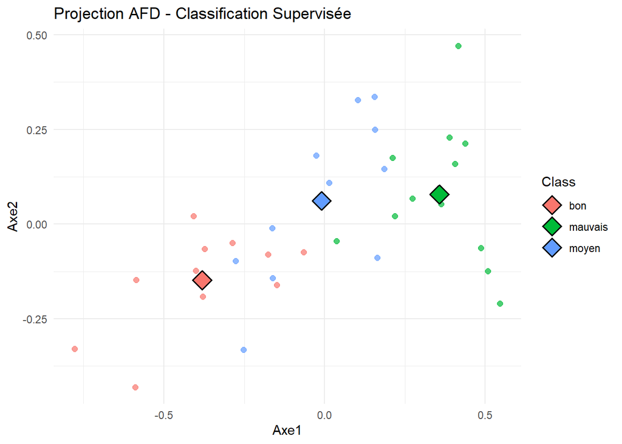

```r
# Affichage du graphique
AFD_graph1(res_afd$Scores)
```

#### 3.2 Distances

- Nous calculons les distances euclidiennes de chaque individu aux différents centre de gravité de chaque groupe.

```r
# Récupération des données
Scores <- res_afd$Scores
K <- nrow(Centres)
N <- nrow(Scores)

# Initialisation de la matrice des distances
Distances <- matrix(NA, nrow = N, ncol = K)
colnames(Distances) <- Centres$Class

# Boucle pour calculer la distance Euclidienne pour chaque classe
for(k in 1:K) {
  xc <- Centres[k, "Axe1"]
  yc <- Centres[k, "Axe2"]

  # Formule distance Euclidienne
  Distances[, k] <- sqrt((Scores$Axe1 - xc)^2 + (Scores$Axe2 - yc)^2)
}

kable(head(Distances), caption = "Distances aux centres de gravité") %>%
  kable_styling(full_width = F)
```

Distances aux centres de gravité

| bon | mauvais | moyen |
| --- | --- | --- |
| 0.6385176 | 0.1848165 | 0.2122292 |
| 0.8951234 | 0.1560913 | 0.4720415 |
| 0.5486804 | 0.2556074 | 0.2294416 |
| 0.8891277 | 0.2521748 | 0.5492198 |
| 0.2156632 | 0.5572735 | 0.2193101 |
| 0.1718110 | 0.7669844 | 0.4000029 |

- Comme le montre la figure, L’affectation d’un individu correspond à la distance minimale entre cet individu et le centre de gravité d’un groupe (figure = groupe 3)

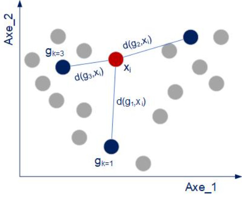

#### 3.3 Classification

Le dataframe suivant compare la classification obtenue par l’AFD et les observations (Gold Standard)

```r
# Identification de l'indice de la distance minimale pour chaque ligne
index_min <- apply(Distances, 1, which.min)

# Récupération du nom de la classe correspondante
Prediction <- colnames(Distances)[index_min]

# Création du dataframe comparant la réalité (Observed) et la prédiction (Predicted)
Resultats_Classif <- data.frame(
  Observed = Y,
  Predicted = as.factor(Prediction)
)

kable(head(Resultats_Classif), caption = "Comparaison Réalité vs Prédiction") %>%
  kable_styling(full_width = F)
```

Comparaison Réalité vs Prédiction

| Observed | Predicted |
| --- | --- |
| moyen | mauvais |
| mauvais | mauvais |
| moyen | moyen |
| mauvais | mauvais |
| bon | bon |
| bon | bon |

#### 3.4 Qualité

- Nous pouvons maintenant réaliser la matrice des confusions en utilisant la fonction *confusionMatrix* du package *caret*

```r
# Calcul de la matrice de confusion
conf_mat <- confusionMatrix(data = Resultats_Classif$Predicted,
                            reference = Resultats_Classif$Observed)

conf_mat
```

```
## Confusion Matrix and Statistics
##
##           Reference
## Prediction bon mauvais moyen
##    bon      10       0     3
##    mauvais   0      11     1
##    moyen     1       1     7
##
## Overall Statistics
##
##                Accuracy : 0.8235
##                  95% CI : (0.6547, 0.9324)
##     No Information Rate : 0.3529
##     P-Value [Acc > NIR] : 2.403e-08
##
##                   Kappa : 0.7351
##
##  Mcnemar's Test P-Value : NA
##
## Statistics by Class:
##
##                      Class: bon Class: mauvais Class: moyen
## Sensitivity              0.9091         0.9167       0.6364
## Specificity              0.8696         0.9545       0.9130
## Pos Pred Value           0.7692         0.9167       0.7778
## Neg Pred Value           0.9524         0.9545       0.8400
## Prevalence               0.3235         0.3529       0.3235
## Detection Rate           0.2941         0.3235       0.2059
## Detection Prevalence     0.3824         0.3529       0.2647
## Balanced Accuracy        0.8893         0.9356       0.7747
```

#### 3.5 Encapsulation

- On construit une fonction ( que nous appelerons *AFD_Classif*) et qui “encapsule” le code

La fonction doit retourner :

- les centre de gravités
- les distances de chaque individus aux centre des classes (groupes)
- la comparaison entre la classification réalisée par l’AFD et le gold standard
- la matrice de confusion (obtenue à l’aide de la fonction caret)

```r
# Fonction générique de classification supervisée
AFD_Classif <- function(Scores_df) {

  # Calcul des centres de gravité
  Centres <- aggregate(cbind(Axe1, Axe2) ~ Class, data = Scores_df, mean)

  # Calcul des distances aux centres
  K <- nrow(Centres)
  N <- nrow(Scores_df)
  Distances <- matrix(NA, nrow = N, ncol = K)
  colnames(Distances) <- Centres$Class

  for(k in 1:K) {
    xc <- Centres[k, "Axe1"]
    yc <- Centres[k, "Axe2"]
    Distances[, k] <- sqrt((Scores_df$Axe1 - xc)^2 + (Scores_df$Axe2 - yc)^2)
  }

  # Classification
  index_min <- apply(Distances, 1, which.min)
  Prediction <- colnames(Distances)[index_min]

  Resultats <- data.frame(
    Observed = Scores_df$Class,
    Predicted = factor(Prediction, levels = levels(Scores_df$Class))
  )

  # Matrice de confusion
  Conf_Mat <- confusionMatrix(Resultats$Predicted, Resultats$Observed)

  # Retour des résultats
  return(list(
    Centres = Centres,
    Distances = Distances,
    Classification = Resultats,
    Confusion = Conf_Mat
  ))
}
```

### 4. Déploiement

- Pour déployer le code, on utilisera le fichier *iris* fournit par défaut dans R

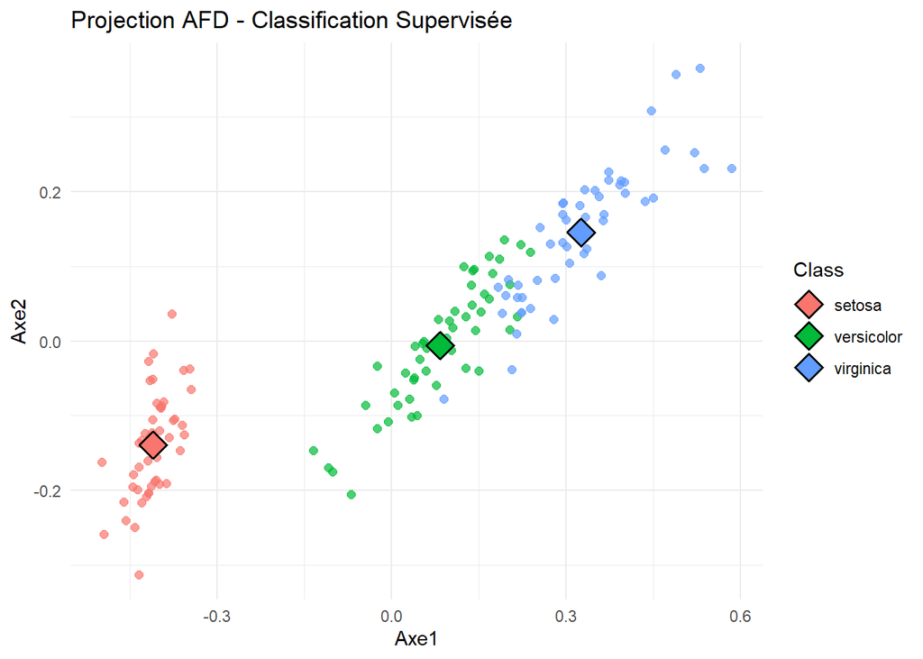

```r
# à compléter
# Chargement et préparation des données Iris
data(iris)
X_iris <- iris[, 1:4]
Y_iris <- iris$Species

# Calcul des matrices d'inertie (MANOVA)
manova_iris <- MANOVA(X_iris, Y_iris)

# Calcul de l'AFD
afd_iris <- AFD(X_iris, Y_iris,
                manova_iris$SS_tot,
                manova_iris$SS_Intra,
                manova_iris$SS_Inter)

# Classification supervisée
res_classif_iris <- AFD_Classif(afd_iris$Scores)

# Visualisation graphique du résultat sur Iris
AFD_graph1(afd_iris$Scores)
```

Les résultats sur le fichier *iris* sont les suivants

- Centres de gravité

```r
kable(res_classif_iris$Centres, caption = "Centres de gravité (Iris)") %>%
  kable_styling(full_width = F)
```

Centres de gravité (Iris)

| Class | Axe1 | Axe2 |
| --- | --- | --- |
| setosa | -0.4104933 | -0.1394087 |
| versicolor | 0.0841946 | -0.0058853 |
| virginica | 0.3262988 | 0.1452940 |

- Distances (Aperçu)

```r
kable(head(res_classif_iris$Distances), caption = "Distances (Iris)") %>%
  kable_styling(full_width = F)
```

Distances (Iris)

| setosa | versicolor | virginica |
| --- | --- | --- |
| 0.0127228 | 0.5170440 | 0.7932238 |
| 0.0646891 | 0.5407477 | 0.8230152 |
| 0.0664077 | 0.5632204 | 0.8442770 |
| 0.0699450 | 0.5457927 | 0.8282454 |
| 0.0213466 | 0.5223978 | 0.7977437 |
| 0.1134302 | 0.4437842 | 0.7089576 |

- Classification (Aperçu)

```r
kable(head(res_classif_iris$Classification), caption = "Classification (Iris)") %>%
  kable_styling(full_width = F)
```

Classification (Iris)

| Observed | Predicted |
| --- | --- |
| setosa | setosa |
| setosa | setosa |
| setosa | setosa |
| setosa | setosa |
| setosa | setosa |
| setosa | setosa |

- Confusion

```r
res_classif_iris$Confusion
```

```
## Confusion Matrix and Statistics
##
##             Reference
## Prediction   setosa versicolor virginica
##   setosa         50          0         0
##   versicolor      0         45         8
##   virginica       0          5        42
##
## Overall Statistics
##
##                Accuracy : 0.9133
##                  95% CI : (0.8564, 0.953)
##     No Information Rate : 0.3333
##     P-Value [Acc > NIR] : < 2.2e-16
##
##                   Kappa : 0.87
##
##  Mcnemar's Test P-Value : NA
##
## Statistics by Class:
##
##                      Class: setosa Class: versicolor Class: virginica
## Sensitivity                 1.0000            0.9000           0.8400
## Specificity                 1.0000            0.9200           0.9500
## Pos Pred Value              1.0000            0.8491           0.8936
## Neg Pred Value              1.0000            0.9485           0.9223
## Prevalence                  0.3333            0.3333           0.3333
## Detection Rate              0.3333            0.3000           0.2800
## Detection Prevalence        0.3333            0.3533           0.3133
## Balanced Accuracy           1.0000            0.9100           0.8950
```